# Chapter 8: R Commands for ANOVA

Author

Dr. Nordmoe

(Note: This R guide for ANOVA is adapted from the *Lock5 with R companion to Statistics:Unlocking the Power of Data* by Randall Pruim and Lana Park.)

# 8.1 Analysis of Variance

## Overview

- Two variables: categorical explanatory and quantitative response
  - Can be used in either experimental or observational designs.
- Main Question: Does the population mean response depend on the (treatment) group?
  - $H_0$: the population group means are all equal ($\mu_1 = \mu_2=\cdots=\mu_k$
  - $H_a$: the population group means are not all equal
- If categorical variable has only 2 values, we already have a method: 2-sample $t$-test
  - ANOVA allows for 3 or more groups (sub-populations)
- $F$ statistic compares within group variation (how different are individuals in the same group?) to between group variation (how different are the different group means?)
- ANOVA assumes that each group is normally distributed with the same (population) standard deviation.
  - Check normality from data plots; normality more critical for small samples. In practice, watch out for clear skewness or extreme outliers if the sample size is small.
  - Check equal standard deviation using 2:1 ratio rule (largest standard deviation at most twice the smallest standard deviation).

## Null and Alternative Hypotheses

### Example 8.1

Are some kinds of sandwiches likely to attrach ants more than others?

```r
favstats(Ants ~ Filling, data = SandwichAnts)
```

```
        Filling min    Q1 median    Q3 max  mean       sd n missing
1 Ham & Pickles  34 42.00   51.0 55.25  65 49.25 10.79352 8       0
2 Peanut Butter  19 21.75   30.5 44.00  59 34.00 14.62874 8       0
3      Vegemite  18 24.00   30.0 39.00  42 30.75  9.25434 8       0
```

**Summary Plots**

Obtain an overview using a boxplot:

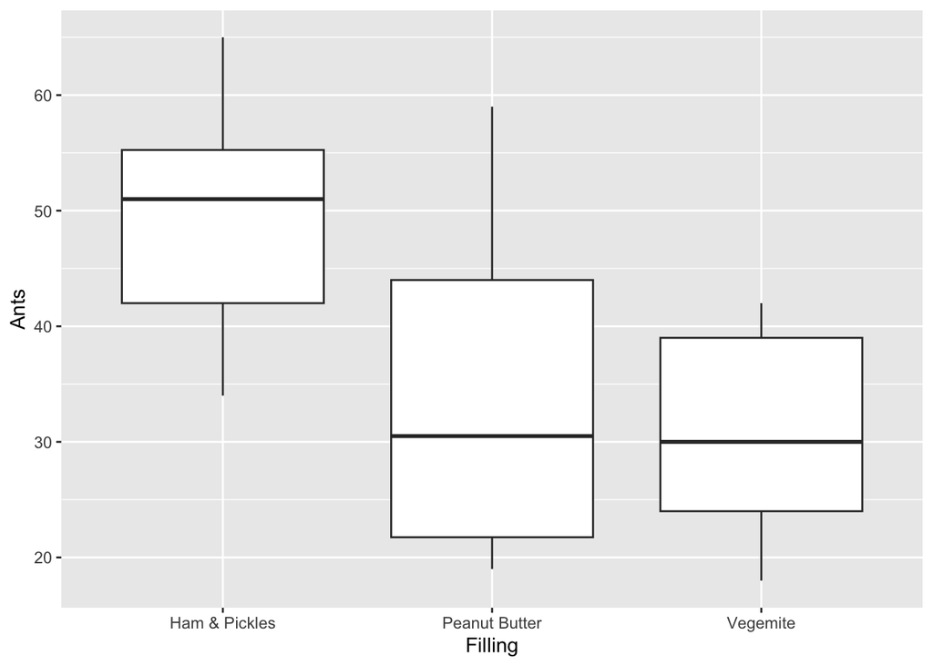

```r
gf_boxplot(Ants ~ Filling, data = SandwichAnts)
```

Get more details by using dotplots:

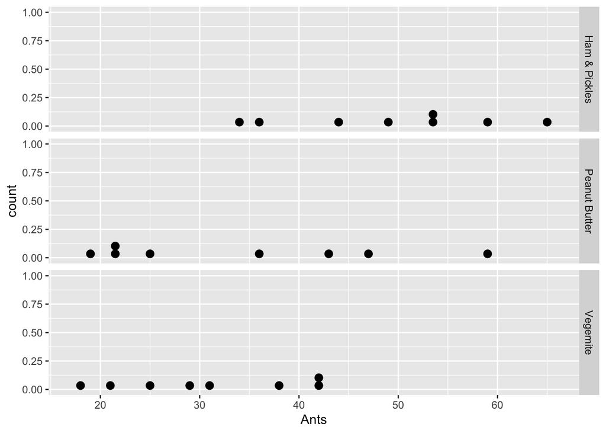

```r
gf_dotplot(~Ants | Filling ~ ., data = SandwichAnts, dotsize = 0.5)
```

Can also overlay the mean on the dotplots, but things are getting pretty complicated now!

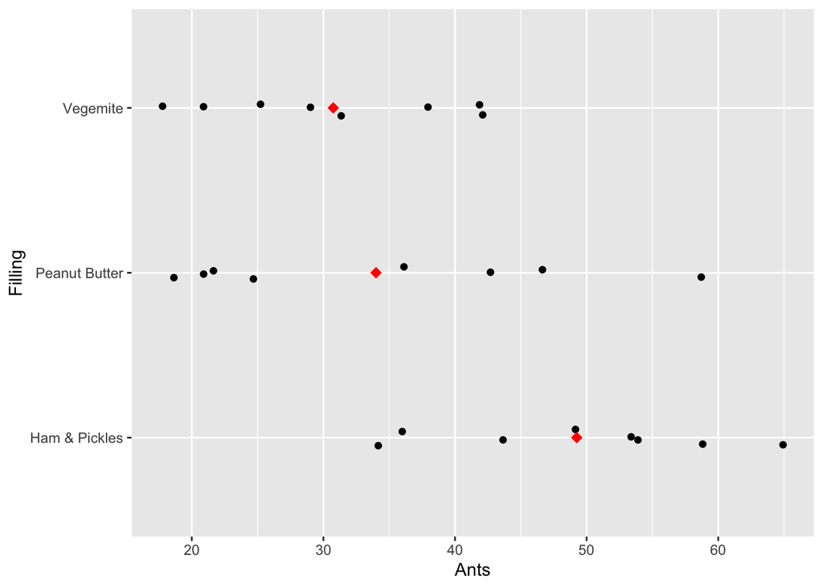

```r
gf_jitter(Filling ~ Ants, data = SandwichAnts, height = 0.05) |>
  gf_summary(fun.x=mean, geom = "point", shape = 18, size =3,
             color = "red")
```

We see there is variability *between* the means as well as *within* the groups. The question is whether the variability in means is too great to be explained by chance variability.

## Carrying out ANOVA and Partitioning Variability

### Example 8.3

```r
Ants.Model <- lm(Ants ~ Filling, data = SandwichAnts)
anova(Ants.Model)
```

```
Analysis of Variance Table

Response: Ants
          Df Sum Sq Mean Sq F value Pr(>F)
Filling    2   1561   780.5   5.627  0.011 *
Residuals 21   2913   138.7
---
Signif. codes:  0 '***' 0.001 '**' 0.01 '*' 0.05 '.' 0.1 ' ' 1
```

The $p$-value listed in this output (`Pr(>F)=0.01105`) is the $p$-value for our null hypothesis that the mean population response is the same in each treatment group. In this case, our test would provide fairly strong evidence against the null hypothesis in favor of the alternative that there is a difference somewhere among the means.

In the next section we’ll look at this test in more detail, but notice that if you know the assumptions of a test, the null hypothesis being tested, and the $p$-value, you can generally interpret the results even if you don’t know all the details of how the test statistic is computed.

## The F-Statistic

The ANOVA test statistic (called $F$) is based on three ingredients:

1. how different the group means are (between group differences)
2. the amount of variability within each group (within group differences)
3. sample size

Each of these is involved in the calculation of $F$.

## The F-distribution

Under certain conditions, the $F$ statistic has a known distribution (called the $F$ distribution). Those conditions are  
1. The null hypothesis is true (i.e., each group has the same mean)  
2. Each group is sampled from a normal population  
3. Each population group has the same standard deviation

When these conditions are met, we can use the $F$-distribution to compute the $p$-value without generating the randomization distribution.

## More Examples of ANOVA

Use ANOVA to explore whether pulse rate is related to Award desired.

```r
head(StudentSurvey,3)
```

```
       Year Sex Smoke   Award HigherSAT Exercise TV Height Weight Siblings
1    Senior   M    No Olympic      Math       10  1     71    180        4
2 Sophomore   F   Yes Academy      Math        4  7     66    120        2
3 FirstYear   M    No   Nobel      Math       14  5     72    208        2
  BirthOrder VerbalSAT MathSAT  SAT  GPA Pulse Piercings
1          4       540     670 1210 3.13    54         0
2          2       520     630 1150 2.50    66         3
3          1       550     560 1110 2.55   130         0
```

Summary statistics of `Pulse`

```r
favstats(~Pulse, data = StudentSurvey)
```

```
 min Q1 median    Q3 max    mean      sd   n missing
  35 62     70 77.75 130 69.5746 12.2051 362       0
```

Summary statistics by `Award` sought:

```r
favstats(Pulse ~ Award, data = StudentSurvey)
```

```
    Award min   Q1 median Q3 max    mean      sd   n missing
1 Academy  42 64.5     71 76  95 70.5161 12.3582  31       0
2   Nobel  40 65.0     72 80 130 72.2148 13.0909 149       0
3 Olympic  35 60.0     68 74  96 67.2527 10.9707 182       0
```

Carry out the ANOVA:

```r
anova(lm(Pulse ~ Award, StudentSurvey))
```

```
Analysis of Variance Table

Response: Pulse
           Df Sum Sq Mean Sq F value   Pr(>F)
Award       2   2047  1023.6   7.104 0.000943 ***
Residuals 359  51729   144.1
---
Signif. codes:  0 '***' 0.001 '**' 0.01 '*' 0.05 '.' 0.1 ' ' 1
```

The low $p$-value is evidence that mean pulse rates differ across groups, assuming the conditions for the ANOVA hold.

**Figure 8.5**

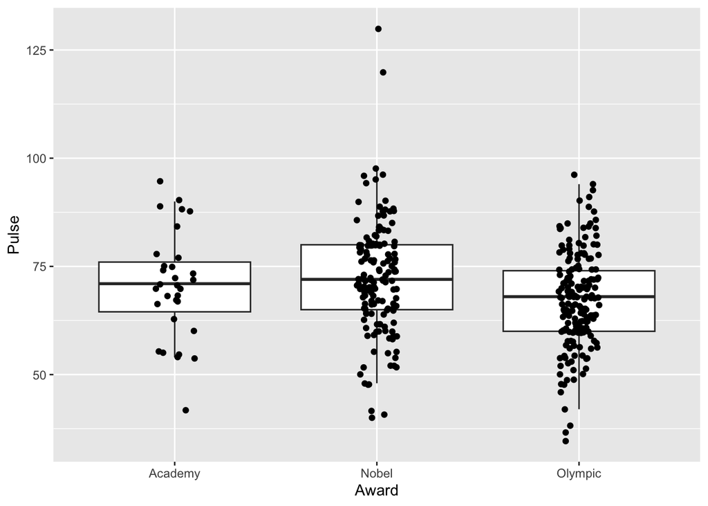

```r
gf_boxplot(Pulse ~ Award, data = StudentSurvey, outlier.shape = NA) |>
  gf_jitter(width = .1)
```

# 8.2 Pairwise Comparisons and Inference After ANOVA

## Using ANOVA for Inferences about Group Means

In Chapter 6 we used formulas for doing inference (either confidence intervals or tests) for a single mean and differences in two means. If we have found an ANOVA table based on samples from several groups, we make a couple of small adjustments to the computations in the Chapter 6 formulas:

- Estimate any standard deviation with the common $MSE$ from the ANOVA table.
- Use the error degrees of freedom, $n - k$, for any $t$-distributions.

For example, to find a confidence interval for the mean of the $i$th group, we use
$$\bar x_i \pm t^* \frac{\sqrt{\text{MSE}}}{\sqrt{n_i}}$$

**Example 8.7**

```r
#Referring to the Ants.Model created with the lm() command above:
anova(Ants.Model)
```

```
Analysis of Variance Table

Response: Ants
          Df Sum Sq Mean Sq F value Pr(>F)
Filling    2   1561   780.5   5.627  0.011 *
Residuals 21   2913   138.7
---
Signif. codes:  0 '***' 0.001 '**' 0.01 '*' 0.05 '.' 0.1 ' ' 1
```

```r
MSE <- 138.71
mean(Ants ~ Filling, data = SandwichAnts)
```

```
Ham & Pickles Peanut Butter      Vegemite
        49.25         34.00         30.75
```

Use Tukey’s HSD method (not mentioned in the text) to get pairwise comparisons for *all* pairs of means:

```r
TukeyHSD(Ants.Model)
```

```
  Tukey multiple comparisons of means
    95% family-wise confidence level

Fit: aov(formula = x)

$Filling
                              diff      lwr       upr    p adj
Peanut Butter-Ham & Pickles -15.25 -30.0933 -0.406736 0.043349
Vegemite-Ham & Pickles      -18.50 -33.3433 -3.656736 0.013101
Vegemite-Peanut Butter       -3.25 -18.0933 11.593264 0.846638
```

The results can also be plotted to help visualize the differences in means:

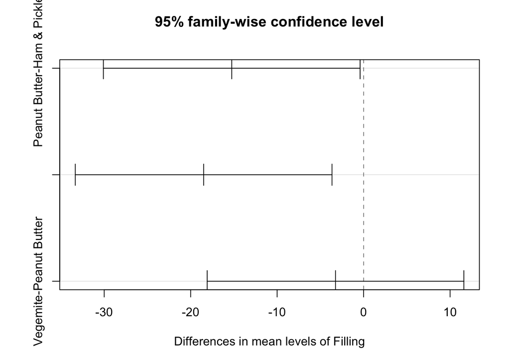

```r
plot(TukeyHSD(Ants.Model))
```

## Lots of Pairwise Comparisons

**Example 8.10**

```r
head(TextbookCosts,3)
```

```
           Field Books Cost
1  SocialScience     3   77
2 NaturalScience     2  231
3 NaturalScience     1  189
```

**Summary statistics and plot**

```r
favstats(Cost ~ Field, data = TextbookCosts)
```

```
           Field min     Q1 median     Q3 max  mean      sd  n missing
1           Arts  17  70.25  105.5 127.75 153  94.6 44.9474 10       0
2     Humanities  57  77.75  111.0 132.75 223 120.3 58.1455 10       0
3 NaturalScience 110 132.25  168.5 205.50 246 170.8 48.4924 10       0
4  SocialScience  73  85.50   94.5 149.50 199 118.3 48.8991 10       0
```

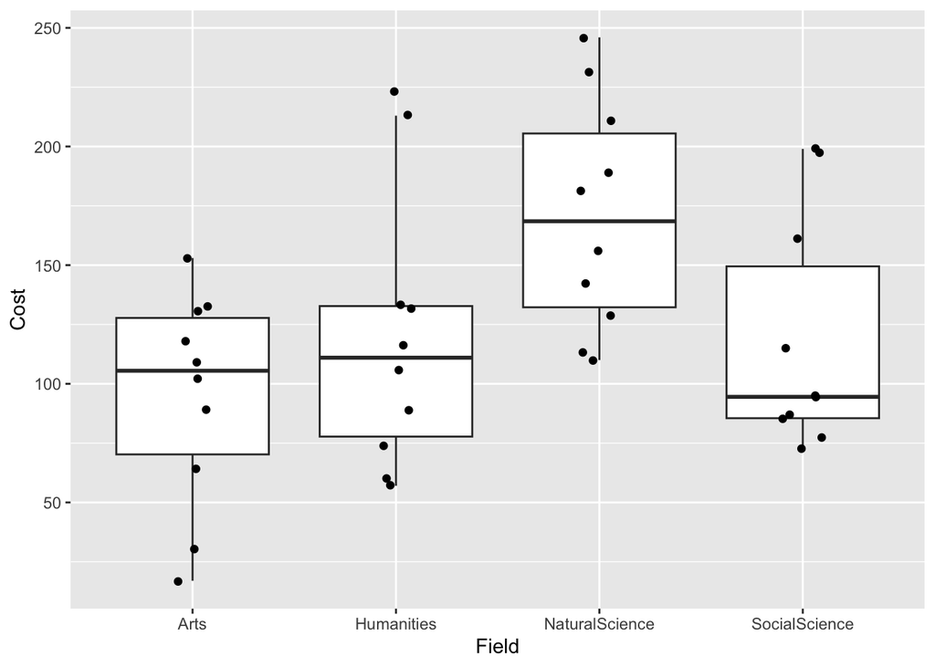

```r
gf_boxplot(Cost ~ Field, data = TextbookCosts, outlier.shape = NA) |>
  gf_jitter(width = 0.1)
```

Get pairwise comparisons among the mean prices of textbooks from different fields:

```r
Books.Model <- lm(Cost ~ Field, data = TextbookCosts)
anova(Books.Model)
```

```
Analysis of Variance Table

Response: Cost
          Df Sum Sq Mean Sq F value Pr(>F)
Field      3  30848   10283   4.055  0.014 *
Residuals 36  91294    2536
---
Signif. codes:  0 '***' 0.001 '**' 0.01 '*' 0.05 '.' 0.1 ' ' 1
```

```r
# This method (Tukey) is better than method in the text
# because it controls for multiple comparisons.
TukeyHSD(Books.Model)
```

```
  Tukey multiple comparisons of means
    95% family-wise confidence level

Fit: aov(formula = x)

$Field
                              diff       lwr       upr    p adj
Humanities-Arts               25.7  -34.9538  86.35384 0.666914
NaturalScience-Arts           76.2   15.5462 136.85384 0.009015
SocialScience-Arts            23.7  -36.9538  84.35384 0.720102
NaturalScience-Humanities     50.5  -10.1538 111.15384 0.131237
SocialScience-Humanities      -2.0  -62.6538  58.65384 0.999744
SocialScience-NaturalScience -52.5 -113.1538   8.15384 0.109776
```